```
Aula 6 - 09/10/2020
```

# Estatística de Weibull - Uma Ferramenta de Conversão e Comparação de Comportamentos Mecânicos

## Tópicos:

### Distribuições Estatísticas (Normal e de Weibull)

### Considerações Finais

[figure not shown]

# Referências:

### Wachtman, Mechanical Properties of Ceramics Páginas 119-136

### Kendall et al, Influence of toughness on Weibull modulus of ceramic bending strength

### Zwaag et al, The concept of filament strength and the Weibull modulus

# Introdução

O comportamento mecânico dos materiais é **fundamental** para sua aplicação **segura**, seja em *componentes de máquinas*, ou quando usado como *material estrutural*.

Sendo assim, caracterizá-lo é de grande importância:

[figure not shown]

**Figura 1:** Ensaio de Flexão de Alumina e um vidro sodalime.

Em um ensaio, aplica-se a carga (ou deslocamento) no material, até atingir sua falha. Esta é caracterizada (para materiais frágeis fraturando de forma catastrófica) como a queda repentina da tensão.

# Mas onde o material falhou?

Uma maneira de responder essa pergunta é através da análise das tensões em um corpo sujeito a flexão em 3 pontos.

Isto pode ser feito de maneira analítica (como na disciplina Mecânica dos Sólidos) ou de maneira numérica como através da simulação por elementos finitos abaixo:

[figure not shown]

**Figura 2:** Simulação de Elementos Finitos de um Ensaio Flexão. Mapa de calor da tensão no material.

Este resultado pode ser avaliado também pela deformação no corpo de prova, como também é possível observar na malha deformada abaixo:

[figure not shown]

**Figura 3:** Simulação de Elementos Finitos de um Ensaio Flexão. Mapa de calor da tensão no material, considerando deformação (exagerada).

Isso vale para um material **perfeito** (sem defeitos), porém, devemos lembrar que os defeitos são **intrínsecos** ao material! Sendo assim, a pergunta contínua:

*Onde o material falhou?*

Lembrando que defeitos concentram tensões, não é só o local da falha, mas também a resistência mecânica que dependerá das suas posições e características. Como exemplo, consideremos 3 possíveis defeitos:

[figure not shown]

O material pode romper em alguns possíveis cenários como:

- Romper na superfície inferior, onde a tração é máxima, assim que alcançar o limite
- Romper no defeito 1, caso a combinação de tensão trativa local, geometria e tamanho do defeito resultarem no $\sigma_{th}$
- Romper no defeito 2
- Romper no defeito 3

# Em síntese:

O valor de resistência mecânica vai depender dos seguintes fatores:

1. Tamanho (e geometria) do defeito
2. Posição do defeito no corpo
3. Orientação do defeito relativa ao corpo

Todas estas características serão **dependentes** de fatores *determinísticos* (parâmetros de processamento, matérias-primas, aditivos, ...), e *estocásticos* e assim, dentro de uma amostra de $n$ corpos de um mesmo material teremos uma **distribuição** de valores de resistência mecânica.

Assim, temos três consequências principais:

- O uso do $\sigma_f$ médio **não é apropriado** para **projetos** de estruturas ou componentes
- A **probabilidade** de falha de uma peça **maior é maior** do que o de uma peça menor
- O valor de resistência mecânica obtido **depende da técnica utilizada** (já que diferentes técnicas **solicitam diferentes volumes** do material em **tração**)

Dessa forma, apresentaremos **ferramentas estatísticas** para tratar estes dados e poder **quantificar** o comportamento geral de um dado material.

Começaremos com uma breve **revisão estatística** e em seguida introduziremos **análises** passíveis de serem feitas usando estas ferramentas e os **conceitos já vistos no curso**.

# Distribuições Estatísticas

Começemos considerando uma distribuição de uma variável contínua, no caso uma amostra de 10000 pessoas nas quais se perguntou a sua altura. Nós podemos visualizar o resultado através de um histograma:

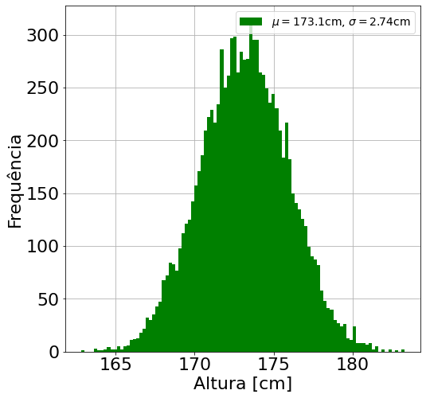

**Figura 5:** Resultados de uma pesquisa feita com 10000 pessoas sobre suas alturas.

Nós podemos aproximar os dados coletados por uma curva de distribuição (ou função) de densidade de probabilidade, a FDP, levando a espessura da barra para zero.

Outra forma de visualizar estes resultados é através da função de distribuição acumulada, a FDA, que apresenta qual a fração da amostra que tem um valor igual ou menor do que determinado valor.

[figure not shown]

## Efeito dos Parâmetros em uma Distribuição Normal

Estas funções podem ser interpoladas dos dados experimentais

Devido o fato de que **um grande número de fenômenos** serem representados por um **pequeno número de funções analíticas**, estas ditribuições possuem nomes próprios:

- Distribuição **normal** (Gaussiana)
- Distribuição de Pareto
- Distribuição Logística
- Distribuição de Cauchy
- Distribuição de Boltzmann
- *Distribuição de Weilbull*

## A Distribuição de Weibull

A função de distribuição de Weibull é definida pela seguinte função de distribuição acumulada:

\begin{equation} P_{f}(\sigma)=\left\{\begin{array}{ll} 1-e ^{-\left(\frac{\sigma-\sigma_{u}}{\sigma_{0}}\right)^{m}} & \sigma>\sigma_{u} \\ 0 & \sigma \leq \sigma_{u} \end{array}\right. \end{equation}

Os gráficos a seguir demonstram a sua FDP e FDA:

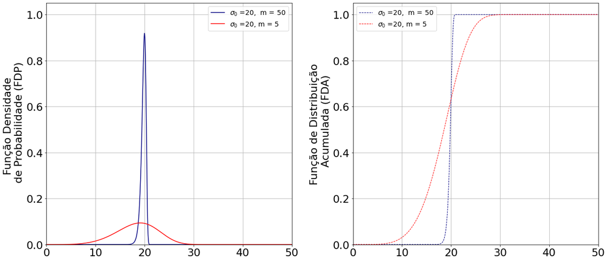

**Figura 7:** Exemplos de distribuição de Weibull com diferentes parâmetros apresentados pela Função de Distribuição Acumulada e Função Densidade de Probabilidade.

# Por que usar a distribuição de Weibull?

A distribuição de Weibull é **qualitativamente** próxima de uma distribuição normal:

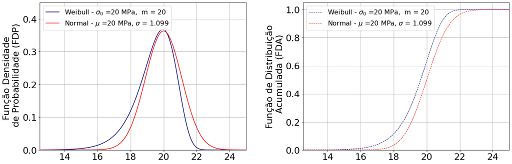

**Figura 8:** Comparação de uma distribuição Normal e uma distribuição de Weibull.

## Então, por que usar a distribuição de Weibull?

# Por que usar a distribuição de Weibull?

- Em primeiro lugar, a distribuição normal é consideravelmente mais complexa:

[output not shown]

Isto seria **problemático** para as etapas posteriores da **Análise de Weibull**!

- Em segundo lugar, observe que a distribuição normal admite **valores negativos** para a **resistência mecânica**!

## Efeito dos Parâmetros na Distribuição de Weibull

Qual o sentido físico dos parâmetros de Weibull?

# Análise de Weibull Aplicada na Resistência Mecânica do Material

[figure not shown]

**Figura 9:** Da Vinci e representação de sua teoria.

A análise de Weibull é inspirada na Teoria do Elo Mais Fraco (proposta por Aristóteles e revisitada por Leonardo Da Vinci):

> "*Uma corrente é tão forte quanto o for o seu elo mais fraco.*"

> "*Quanto maior a corrente, maior a é a propabilidade de que ela falhe quando uma carga é aplicada.*"

Esta teoria considera fraturas frágfeis em uma escala marcoscópica.

# Análise de Weibull Aplicada na Resistência Mecânica do Material

Todo material solicitado por uma carga está sujeito a uma probabilidade de falha, $P_f$

Esta, pode ser representada matematicamente como:

\begin{equation} P_f = 1 - P_S \end{equation}

Onde $P_S$ é a probabilidade de sobrevivência do material.

Nós podemos assumir estas quantias como funções da tensão ao qual o material está sujeito, $\sigma$ e devido a teoria do elo mais fraco, do volume $V$:

\begin{equation} P_f(\sigma, V) = 1 - P_S(\sigma, V) \end{equation}

# Análise de Weibull Aplicada na Resistência Mecânica do Material

Para conduzir a análise, consideremos o que ocorre em um determinado corpo de volume $V + \delta V$. Este corpo apenas sobreviverá se ambas as partes sobreviverem, isto a probabilidade combinada de ambos os cenários devem ser considerados. Matematicamente:

\begin{equation} P_S(V + \delta V) = P_S(V) \ P_S(\delta V) \end{equation}

Se considerarmos que a distribuição de probabilidades de falha é descrita por uma densidade de porbabilidade $\varphi(\sigma)$ (isto é, uma função que retorna o valor de probabilidade de um volume infinitesimal falhar para uma dada aplicação de uma tensão local $\sigma$), temos:

\begin{equation} P_s(\sigma, \delta V) = 1 - P_f(\sigma, \delta V) = 1 - \varphi(\sigma) \ \delta V \end{equation}

Substituindo na Equação (5), e rearranjando temos: \begin{equation} \frac{P_{s}(\sigma, V+\delta V)-P_{s}(\sigma, V)}{\delta V}=-\varphi(\sigma) \ P_{s}(\sigma, V) \end{equation}

# Análise de Weibull Aplicada na Resistência Mecânica do Material

Se reduzirmos o valor de $\delta V$ podemos aproximar a derivada da probabilidade de sobrevivência em função do volume:

\begin{equation} \frac{\partial P_s(\sigma, V)}{\partial V} = - \phi(\sigma) \ P_s(\sigma, V) \end{equation}

Lembrando que a tensão depende da posição e integrando é possível obter $P_s$:

\begin{equation} P_{s}(\sigma, V) = \exp \left\{-\int_{V} \varphi[\sigma(\mathbf{r})] d V\right\} \end{equation}

Usando a Equação 3, podemos achar a probabilidade de falha como sendo: \begin{equation} P_{f}(\sigma, V)=1-P_{s}(\sigma, V)= 1 -\exp \left\{-\int_{V} \varphi[\sigma(\mathbf{r})] d V\right\} \end{equation}

# Análise de Weibull Aplicada na Resistência Mecânica do Material

Para um caso mais simples no qual a tensão independe da posição (por exemplo na caso de uma amostra em tração uniaxial), a Equação 10 se torna: \begin{equation} P_{f}(\sigma, V)=1-P_{s}(\sigma, V) =1-\exp \left\{- V \ \varphi(\sigma) \right\} \end{equation}

Weibull assumiu que $\varphi(\sigma)$ tinha a seguinte forma:

\begin{equation} \varphi(\sigma)=\left(\frac{\sigma}{\Sigma_{0}}\right)^{m} \end{equation}

Finalmente chegando que $P_f$ é dado por:

\begin{equation} P_f = 1 - \exp\left[-V \left(\frac{\sigma}{\Sigma_0}\right)^m\right] \end{equation}

Que é a função de distribuição acumulada de Weibull com parâmetro de escala $\sigma_0$ dado por:

\begin{equation} \sigma_0 = \Sigma_0 \ V^{- \frac{1}{m}} \end{equation}

# Efeito do Volume

Nós iremos avaliar o efeito do volume de uma amostra, usando a probabilidade de falha. Da Equação (13), para um material $a$ com volume $V_a$ e tensão de ruptura $\sigma_a$, temos:

\begin{equation} P_{f,a} = 1 - \exp\left[-V_a \left(\frac{\sigma_a}{\Sigma_0}\right)^m\right] \end{equation}

De maneira análoga para um material $b$ temos: \begin{equation} P_{f,b} = 1 - \exp\left[-V_b \left(\frac{\sigma_b}{\Sigma_0}\right)^m\right] \end{equation}

Podemos considerar um mesmo valor de probabilidade de falha igualando as Equações 15 e 16:

\begin{equation} \exp\left[-V_a \left(\frac{\sigma_a}{\Sigma_0}\right)^m\right] = \exp\left[-V_b \left(\frac{\sigma_b}{\Sigma_0}\right)^m\right] \end{equation}

Se aplicarmos log em ambos os lados temos:

\begin{equation} V_a \left(\frac{\sigma_a}{\Sigma_0}\right)^m = V_b \left(\frac{\sigma_b}{\Sigma_0}\right)^m \end{equation}

Como $\Sigma_0$ independe do volume, podemos cortar o $\left(\frac{1}{\Sigma_0}\right)^m$ de ambos os lados, chegando assim em:

\begin{equation} V_a \sigma_a^m = V_b \sigma_b^m \end{equation}

E rearranjando temos: \begin{equation} \frac{\sigma_a}{\sigma_b} = \left(\frac{V_b}{V_a}\right)^\frac{1}{m} \end{equation}

# Efeito do Volume

É possível comparar tais quantias em um gráfico, podemos ver o efeito de reduzir o tamanho da amostra:

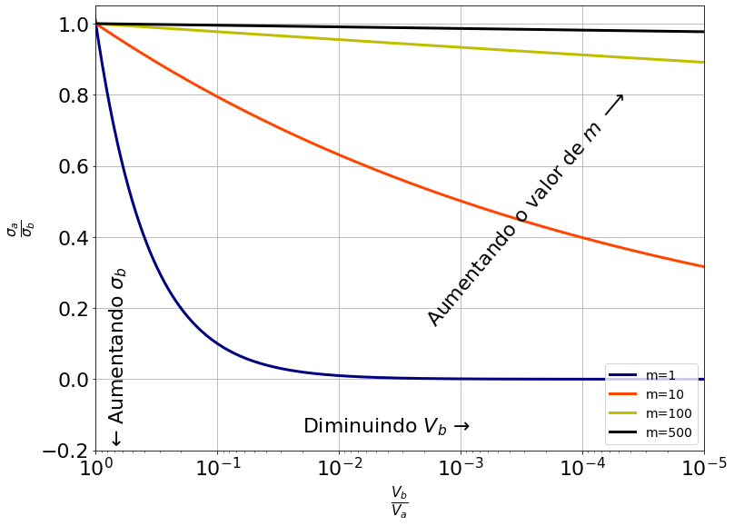

**Figura 10:** Efeito do módulo de Weibull na relação volume da amostra e tensão de ruptura medida.

# Efeito do Ensaio

Nós podemos considerar o efeito do Ensaio na resistência mecânica considerando a forma mais geral da Probabilidade de falha, dada na Equação (10), e considerando a que a tensão pode ser descrita como:

\begin{equation} \sigma(\mathbf{r})=\sigma_{\max } g(\mathbf{r}) \end{equation}

Substituindo na Equação 10, temos: \begin{equation} P_{f}=1-\exp \left[-\left(\frac{\sigma_{\max }}{\Sigma_{0}}\right)^{m} \int_{V} g^{m}(\mathbf{r}) d V\right] \end{equation}

E assim podemos definir o fator do ensaio $k\le1$:

\begin{equation} k=\frac{1}{V} \int_{V} g^{m}(\mathbf{r}) d V \quad \quad \quad \text { ou } \quad \quad \quad k=\frac{1}{V} \int_{V}\left(\frac{\sigma(\mathbf{r})}{\sigma_{\max }}\right)^{m} d V \end{equation}

Dessa maneira temos que a Equação (22) pode ser reescrita como: \begin{equation} P_{f}=1-\exp \left[-k V\left(\frac{\sigma_{\max }}{\Sigma_{0}}\right)^{m}\right] \end{equation}

Calculando o fator do ensaio de fração, temos que $\sigma(\mathbf{r})=\sigma_{max}$ e portanto $k_t$ é dado por:

\begin{equation} k_t = \frac{1}{V} \int_V 1 dV = \frac{1}{V} \iiint dx dy dv = \frac{a \ b \ c}{V} = 1 \end{equation}

Para uma amostra em Flexão em três pontos, um resultado da Mecânica Aplicada indica que: \begin{equation} \frac{\sigma(y)}{\sigma_{max}} = \frac{4 \ x \ y}{L \ h} \end{equation}

[figure not shown]

**Figura 10:** Geometria do Ensaio de Flexão 3 Pontos.

Assim, considerando que o volume solicitado é $V= b \ L \ h$:

\begin{equation} k_{3pt} = \frac{1}{V} \int_{0}^{L}\left(\frac{2 x}{L}\right)^{m} d x \int_{0}^{h / 2}\left(\frac{2 y}{h}\right)^{m} d y \int_{0}^{b} d z= \frac{L \ h \ b}{V \ 2 \ (m+1)^{2}} = \frac{1}{2(m+1)^{2}} \end{equation}

# Efeito do Ensaio

Adotando uma estratégia similar àquela utilizada para a análise do efeito do volume, igualando as probabilidade de falha para um ensaio em tração uniaxial e em flexão três pontos chegamos em:

\begin{equation} \frac{\bar{\sigma}_{3 pt, \max }}{\bar{\sigma}_{t}}=\left(\frac{k_{t}}{k_{3 pt}}\right)^{1 / m}=\left[2(m+1)^{2}\right]^{1 / m} \end{equation}

Usando esta metodologia analítica para o ensaio de quatro pontos resulta em: \begin{equation} \frac{\bar{\sigma}_{4 pt, \max }}{\bar{\sigma}_{t}}=\left(\frac{k_{t}}{k_{4 pt}}\right)^{1 / m}=\left[\frac{4(m+1)^{2}}{m+2}\right]^{1 / m} \end{equation}

Esses comportamentos podem ser visualizados a seguir:

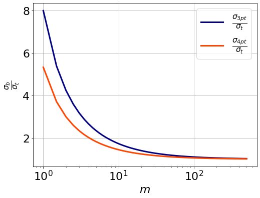

# Como Obter os Parâmetros de Weibull?

Uma forma é através do Gráfico de Weibull. Ele é uma linearização da probabilidade de falha (como a teoria de cristalização de Avrami ou a lei de potências de um fluído não newtoniano)

Para tanto, utiliza-se a aplicação da função log duplamente (uma vez para reduzir a exponenciação e uma segunda para a potência $m$)

\begin{equation} \ln \ln \left(\frac{1}{1-P_{f}}\right) = m \ln\left( \frac{\sigma}{\sigma_{0}}\right) \end{equation}

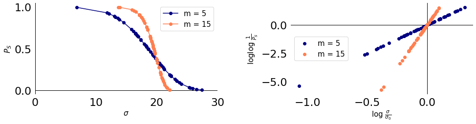

**Figura 11:** Gráfico de Weibull para obtenção dos parâmetros.

# Como Obter os Parâmetros de Weibull?

Entretanto, para este *plot* é necessário a probabilidade de sobrevivência cada corpo. O ensaio em um número n de amostras que compõe a amostra a partir do qual estimamos o módulo de Weibull resulta em:

```
Dados Brutos
```

| Amostra | $\sigma_f$ [MPa] |
| --- | --- |
| 0 | 13.906065 |
| 1 | 21.118875 |
| 2 | 19.755397 |
| ... | ... |
| 57 | 26.676978 |
| 58 | 28.887704 |
| 59 | 12.637076 |

60 rows × 1 columns

```
Dados Ordenados
```

| Amostra | $\sigma_f$ [MPa] | Rank, i |
| --- | --- | --- |
| 7 | 10.467905 | 1 |
| 14 | 11.845441 | 2 |
| 29 | 12.057470 | 3 |
| ... | ... | ... |
| 52 | 26.922920 | 58 |
| 58 | 28.887704 | 59 |
| 28 | 29.707851 | 60 |

60 rows × 2 columns

É possível estimar $P_f$ a partir do rank $i$ seguindo a Equação abaixo:

\begin{equation} P_f(i) = \frac{i-0.3}{n+0.4} \end{equation}

# Como Obter os Parâmetros de Weibull?

| Amostra | $\sigma_f$ [MPa] | Rank, i | P_s | lnln($\frac{1}{P_s}$) | ln($\sigma_f$) |
| --- | --- | --- | --- | --- | --- |
| 7 | 10.467905 | 1 | 0.988411 | -4.451841 | 2.348314 |
| 14 | 11.845441 | 2 | 0.971854 | -3.556120 | 2.471943 |
| 29 | 12.057470 | 3 | 0.955298 | -3.084959 | 2.489684 |
| ... | ... | ... | ... | ... | ... |
| 52 | 26.922920 | 58 | 0.044702 | 1.133895 | 3.292978 |
| 58 | 28.887704 | 59 | 0.028146 | 1.272667 | 3.363416 |
| 28 | 29.707851 | 60 | 0.011589 | 1.494625 | 3.391411 |

60 rows × 5 columns

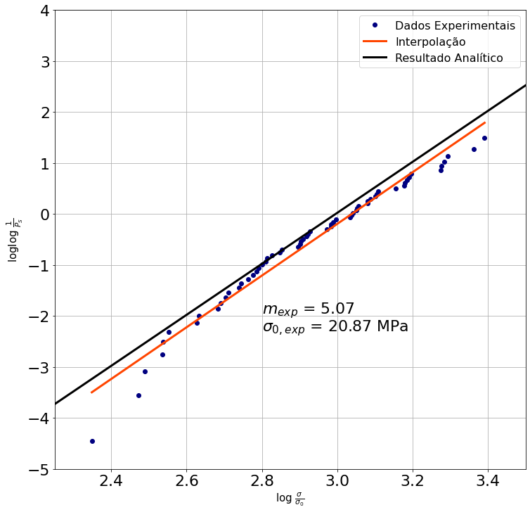

# Alguns Comentários Sobre o Módulo de Weibull:

- Qual o número de corpos de prova que compõe uma amostra para se estimar o módulo?

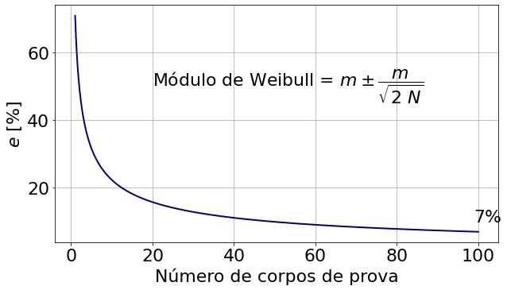

- O módulo de Weibull não está relacionado apenas ao material, mas é influenciado também pela repetibilidade dos CPs
- É necessário se atentar que o comportamento da amostra (de seguir uma distribuição de probabilidade de falha igual ao de Weibull) foi **ASSUMIDO** como sendo o comportamento real. Este caráter *fenomenológico* é uma das principais críticas à analise de Weibull

# Qual Material Possui Maior $m$?

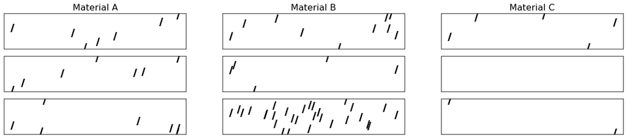

# Observações Experimentais

## Valores comuns de módulo de Weibull

| Materiais Cerâmicos | Materiais Metálicos* | Materiais Poliméricos* |
| --- | --- | --- |
| 5<m<15 | 100<m<500 | 50<m<150 |

## Exemplo da influência do processamento no módulo de Weibull

| Concreto com Cimento Portland | Concreto com Cimento Portland + Dispersante |
| --- | --- |
| m=3,5 | m=20 |

# Observações Experimentais

## O que acontece com o m quando uma amostra a verde é queimada?

[figure not shown]

**Figura 9:** Kendall et al, Influence ot Toughness on Weibull modulus of Ceramics. Efeito da queima no módulo de Weibull.

## Materiais de maior tenacidade a fratura possuem a fama de ser mais confiáveis. Por que?

Efeito dos danos ao longo do tempo de vida do material alteram o módulo de Weibull, especialmente para aqueles materiais onde tais danos ocorrem de maneira mais fácil (menor tenacidade).

# Considerações Finais

- O comportamento mecânico dos materiais é sucetível a diversas fontes de variabilidade (até mesmo erros de medida!)
- Representações matemáticas podem descrever este comportamento (médias, desvios, distribuições estatísticas)
- A probabilidade de falha de um material pode ser descrita por tais distribuições
- Em sua derivação, conceitos clássicos como a teoria do elo mais fraco geraram *insights* de grande importância como o efeito do volume e do ensaio
- O módulo de Weibull descreve a variabilidade de um determinado conjunto de amsotras e serve para:
  - Poder comparar materiais distintos
  - Converter resultados entre corpos de prova de diferentes dimensões e de ensaios distintos